# Projet

Justine LOUARN - Lucie Raimbault - Marion Moussay

4/29/2022

# Synthèse

Notre étude porte sur le nombre de cas de varicelle à Budapest sur une période de 10 ans (2005 - 2015). Dans un premier temps nous avons analysé la série brute, dans laquelle nous avons remarquer une saisonnalité de 52 semaines soit 1 an.

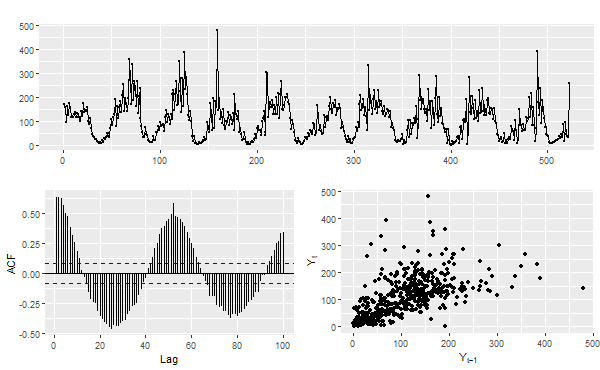

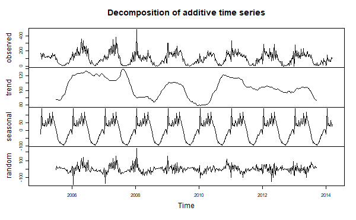

Pour finir nous obtenons donc ce modèle :

$$X_{t} = \hat m_{t}+ \hat s_{t}+ n_{t} +
BB(\sigma^{2}= 1675)$$

$$n_{t} = \hat{a}_{1} n_{t-1}+ \hat{a}_{2}
n_{t-2} + \hat{a}_{3} n_{t-3} + \hat{a}_{4} n_{t-4}$$

# Introduction

La varicelle est une maladie infantile extrêmenment contagieuse, elle est responsable d’une éruption de boutons. Elle guérit en une dizaine de jours. Dans cette étude nous allons nous intéresser au nombre de cas hebdomadaires de varicelle en Hongrie de 2005 à 2015. Nous avons choisis de nous interesser seulement à la ville de Budapest, capitale et plus grande ville de Hongrie (1 752 286 habitants).

Dans ce projet nous avons pour objectif de déployer les outils vus en cours pour essayer d’ajuster un modèle aux données.

Dans un premier temps nous allons analyser notre série brutes puis nous allons déceller ou non une saisonnalité et une tendance, puis nous étudierons les résidus afin de créer un modèle qui s’ajuste à nos données.

## Importation des données

```r
data <- read.csv("hungary_chickenpox.csv")
data$Date <- dmy(data$Date)
mean(colMeans(data[-1]))
```

```
## [1] 38.84282
```

```r
colMeans(data[-1])
```

```
##  BUDAPEST   BARANYA      BACS     BEKES    BORSOD  CSONGRAD     FEJER      GYOR
## 101.24521  34.20498  37.16667  28.91188  57.08238  31.48851  33.27203  41.43678
##     HAJDU     HEVES      JASZ   KOMAROM    NOGRAD      PEST    SOMOGY  SZABOLCS
##  47.09770  29.69157  40.86973  25.64368  21.85057  86.10153  27.60920  29.85441
##     TOLNA       VAS  VESZPREM      ZALA
##  20.35249  22.46743  40.63602  19.87356
```

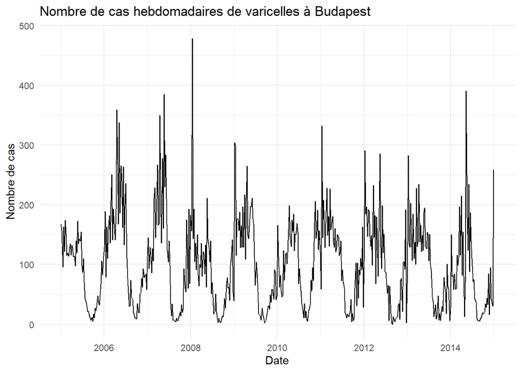

```r
budapest <- data[,1:2]
colnames(budapest) <- c("date", "nb")
budapest %>% ggplot() + aes(x=date, y=nb) + geom_line() + ggtitle("Nombre de cas hebdomadaires de varicelles à Budapest")+theme_minimal()+ xlab("Date")+ylab("Nombre de cas")
```

De cette première représentation, nous remarquons directement une forte saisonnalité d’un an, soit 52 semaines dans notre cas. Nous n’observons pas vraiment de tendance ou alors une légère décroissance mais cela reste difficile à dire avec ce graphique. De plus, on imagine un modèle additif puisque l’on voit une amplitude plutot constante.

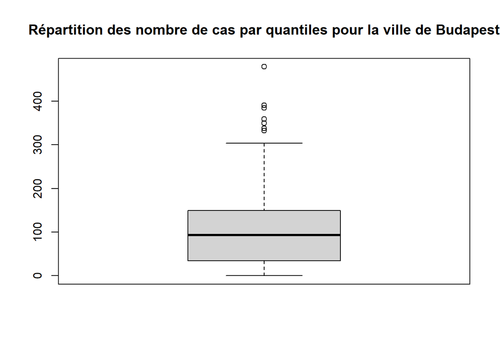

```r
boxplot(budapest$nb, main="Répartition des nombre de cas par quantiles pour la ville de Budapest")
```

Sur le boxplot des données hebdomadaires de varicelles à Budapest, on observe qu’il y a des données hautes, après vérification on ne les considère pas comme abbérantes. Les données étant très propre, nous n’avons pas eu de modifications à faire sur le jeu de données.

## Première approche

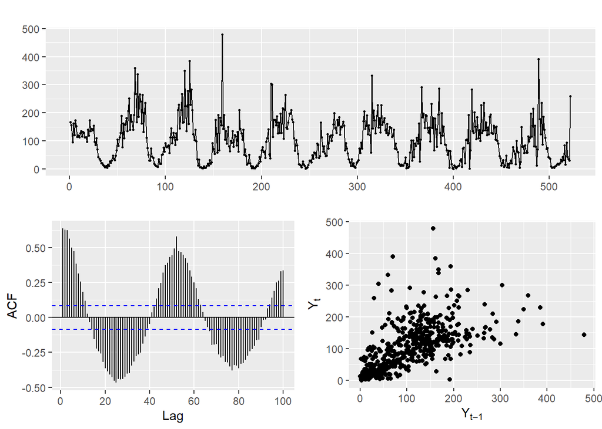

```r
budapest %>% select(nb) %>%
  ggtsdisplay(
    plot.type = "scatter",
    lag.max=100
    )
```

```r
#dev.print(device = png, file = "export.png", width = 600)
```

Pour mieux déterminer la saisonnalité nous allons observer la fonction d’autocorrélation. Elle semble périodique, ce qui indique une périodicité dans la série temporelle. La ligne pointillée bleue indique le niveau en-dessous duquel la corrélation n’est plus statistiquement significative.

Observons l’auto-corrélation de plus près :

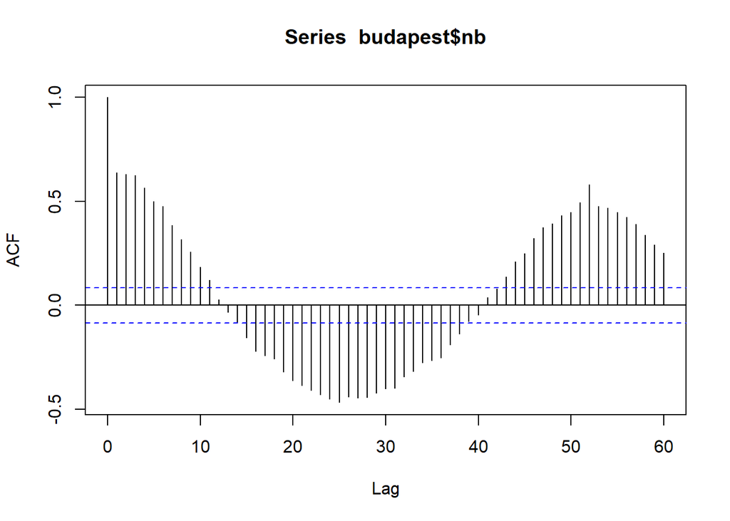

```r
acf(budapest$nb, lag.max = 60)
```

On voit ici que la périodicité est de 52 semaines. En effet chaque donnée est espacée de 7 jours. **T= 52** semaines donc environ 12 mois, soit 1 an.

On regarde l’évolution pour chaque année.

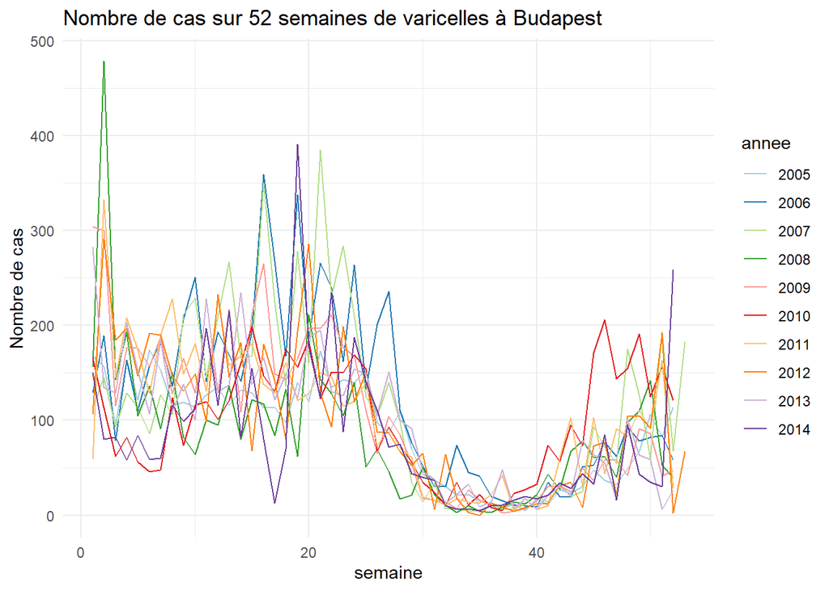

```r
budapest$annee<-factor(year(budapest$date))
budapest$semaine<-week(budapest$date)


ggplot(budapest,aes(x = semaine, y = nb,group=annee,colour=annee)) + geom_line()+scale_color_brewer(palette="Paired")+ ggtitle("Nombre de cas sur 52 semaines de varicelles à Budapest")+theme_minimal()+ xlab("semaine")+ylab("Nombre de cas")+ scale_fill_discrete(name = "Année")
```

Avec cette représentation on observe bien la saisonnalité, le même schéma se reproduit tous les ans. On remarque qu’il y a plus de cas de varicelle au début de l’année (en hiver et au printemps). Durant l’été, il y a peu de cas de varicelles, puis à la fin de l’année le nombre de cas de varicelle augmente. Cela semble logique, d’après santé publique france, la varicelle est une maladie saisonnière, on observe chaque année une hausse des cas au printemps. Il s’agit d’une augmentation attendue de la maladie.